# K Means Clustering

## K Means Clustering Vs Hierarchical Clustering

1. Visual Stand Point - We have Elbow Plot to let us know how many clusters in K Means where as in Hierarchical Clustering, we have Dendrograms that tell us how many clusters can be formed from the data itself.
1. In K Means Clustering, we need to have K Value in Hand for creation of Clusters which means K Value drives the clusters however, in Hierarchical Clustering, there is no Need of K Value as the Hierarchical Clustering works on the theme of Hierarchy.
1. The linkage between the data points in K Means Clustering is done by EUCLIDEAN DISTT however we have several Linkage Approaches in H. Clustering.
1. The K Means is divided in Soft and Hard Clustering however, the H. Clustering is divided in Agglomerative Clustering and Divisive Clustering.

```python
# Importing the Required Libraries
import pandas as pd
import numpy as np
from sklearn.cluster import KMeans # K Means Clustering Deployment Lib
from sklearn.datasets import load_iris # Here we will pull the IRIS
```

```python
# Call the Load Iris
i = load_iris() # This will enable the i variable with the data properties
```

```python
# Creating the Data Frame of IRIS Data
iris = pd.DataFrame(i.data, columns=i.feature_names)
```

```python
iris.head()
```

|  | sepal length (cm) | sepal width (cm) | petal length (cm) | petal width (cm) |
| --- | --- | --- | --- | --- |
| 0 | 5.1 | 3.5 | 1.4 | 0.2 |
| 1 | 4.9 | 3.0 | 1.4 | 0.2 |
| 2 | 4.7 | 3.2 | 1.3 | 0.2 |
| 3 | 4.6 | 3.1 | 1.5 | 0.2 |
| 4 | 5.0 | 3.6 | 1.4 | 0.2 |

```python
i.target
```

```
array([0, 0, 0, 0, 0, 0, 0, 0, 0, 0, 0, 0, 0, 0, 0, 0, 0, 0, 0, 0, 0, 0,
       0, 0, 0, 0, 0, 0, 0, 0, 0, 0, 0, 0, 0, 0, 0, 0, 0, 0, 0, 0, 0, 0,
       0, 0, 0, 0, 0, 0, 1, 1, 1, 1, 1, 1, 1, 1, 1, 1, 1, 1, 1, 1, 1, 1,
       1, 1, 1, 1, 1, 1, 1, 1, 1, 1, 1, 1, 1, 1, 1, 1, 1, 1, 1, 1, 1, 1,
       1, 1, 1, 1, 1, 1, 1, 1, 1, 1, 1, 1, 2, 2, 2, 2, 2, 2, 2, 2, 2, 2,
       2, 2, 2, 2, 2, 2, 2, 2, 2, 2, 2, 2, 2, 2, 2, 2, 2, 2, 2, 2, 2, 2,
       2, 2, 2, 2, 2, 2, 2, 2, 2, 2, 2, 2, 2, 2, 2, 2, 2, 2])
```

```python
i.target_names
```

```
array(['setosa', 'versicolor', 'virginica'], dtype='<U10')
```

```python
import matplotlib.pyplot as plt
import seaborn as sns
```

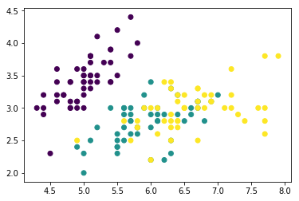

```python
plt.scatter(x = iris["sepal length (cm)"], y = iris["sepal width (cm)"], c = i.target)
```

```python
# from sklearn.cluster import KMeans
k = KMeans()
```

```python
# Fitting the k means clustering algo on the IRIS Data
k.fit(iris)

# Tip: There is no train and test data as it is an UnSup Algo.
# By Default, the no of Clusters in Python is 8.
```

```
KMeans(algorithm='auto', copy_x=True, init='k-means++', max_iter=300,
    n_clusters=8, n_init=10, n_jobs=None, precompute_distances='auto',
    random_state=None, tol=0.0001, verbose=0)
```

```python
# Predicting here means we want to find the labels of the clusters
pred = k.predict(iris)
```

```python
pred
```

```
array([1, 6, 6, 6, 1, 1, 6, 1, 6, 6, 1, 6, 6, 6, 1, 1, 1, 1, 1, 1, 1, 1,
       6, 1, 6, 6, 1, 1, 1, 6, 6, 1, 1, 1, 6, 6, 1, 1, 6, 1, 1, 6, 6, 1,
       1, 6, 1, 6, 1, 6, 5, 5, 5, 3, 5, 7, 5, 3, 5, 3, 3, 7, 7, 5, 3, 5,
       7, 7, 7, 3, 0, 7, 0, 5, 5, 5, 5, 5, 7, 3, 3, 3, 7, 0, 7, 5, 5, 7,
       7, 7, 7, 5, 7, 3, 7, 7, 7, 7, 3, 7, 2, 0, 4, 2, 2, 4, 7, 4, 2, 4,
       2, 0, 2, 0, 0, 2, 2, 4, 4, 0, 2, 0, 4, 0, 2, 4, 0, 0, 2, 4, 4, 4,
       2, 0, 0, 4, 2, 2, 0, 2, 2, 2, 0, 2, 2, 2, 0, 2, 2, 0], dtype=int32)
```

```python
# Find the Cluster Centroids
k.cluster_centers_
```

```
array([[6.02777778, 2.73333333, 5.02777778, 1.79444444],
       [5.24285714, 3.66785714, 1.5       , 0.28214286],
       [6.56818182, 3.08636364, 5.53636364, 2.16363636],
       [5.32727273, 2.45454545, 3.59090909, 1.11818182],
       [7.475     , 3.125     , 6.3       , 2.05      ],
       [6.49375   , 3.03125   , 4.63125   , 1.44375   ],
       [4.70454545, 3.12272727, 1.41363636, 0.2       ],
       [5.76190476, 2.71904762, 4.24285714, 1.31904762]])
```

### Role of Elbow

Since the K Value by default is 8 which means that it may not be the correct the cluster count and hence we would need the ELBOW Method Approach to find the Correct Cluster Count.

Steps

1. We will create ELBOW Plot to find the Optimal Cluster Count.
2. We will take the Cluster Centres and plot in the Data to see the Centroids in the Plot

```python
# Elbow Plot: Optimal Count Value 20
clusters = range(1,10)
wcss = []
```

```python
for i in clusters: # Defined how many times the loop will run
    k = KMeans(n_clusters=i) # Initiated the Machine
    model = k.fit(iris)
    wcss.append(k.inertia_) # WCSS in real life is called inertia in python:: WCSS Value
```

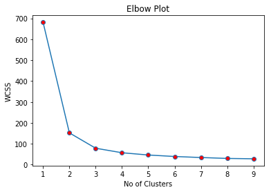

```python
# Plot the Elbow
plt.plot(clusters, wcss, "-o", markerfacecolor = "r")
plt.xlabel("No of Clusters")
plt.ylabel("WCSS")
plt.title("Elbow Plot")
plt.show()
```

```python
# Since we know that the no of clusters = 3
k = KMeans(n_clusters=3)
```

```python
k.fit(iris)
```

```
KMeans(algorithm='auto', copy_x=True, init='k-means++', max_iter=300,
    n_clusters=3, n_init=10, n_jobs=None, precompute_distances='auto',
    random_state=None, tol=0.0001, verbose=0)
```

```python
pred = k.predict(iris)
```

```python
pred
```

```
array([1, 1, 1, 1, 1, 1, 1, 1, 1, 1, 1, 1, 1, 1, 1, 1, 1, 1, 1, 1, 1, 1,
       1, 1, 1, 1, 1, 1, 1, 1, 1, 1, 1, 1, 1, 1, 1, 1, 1, 1, 1, 1, 1, 1,
       1, 1, 1, 1, 1, 1, 2, 2, 0, 2, 2, 2, 2, 2, 2, 2, 2, 2, 2, 2, 2, 2,
       2, 2, 2, 2, 2, 2, 2, 2, 2, 2, 2, 0, 2, 2, 2, 2, 2, 2, 2, 2, 2, 2,
       2, 2, 2, 2, 2, 2, 2, 2, 2, 2, 2, 2, 0, 2, 0, 0, 0, 0, 2, 0, 0, 0,
       0, 0, 0, 2, 2, 0, 0, 0, 0, 2, 0, 2, 0, 2, 0, 0, 2, 2, 0, 0, 0, 0,
       0, 2, 0, 0, 0, 0, 2, 0, 0, 0, 2, 0, 0, 0, 2, 0, 0, 2], dtype=int32)
```

```python
centroid = k.cluster_centers_
```

```python
centroid[:, 1]
```

```
array([3.07368421, 3.428     , 2.7483871 ])
```

```python
k.inertia_ # this is when the K value is 3
```

```
78.85144142614601
```

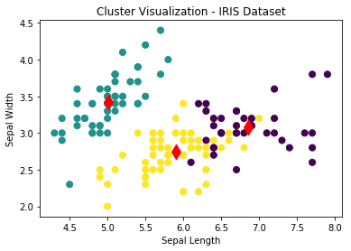

```python
# Plotting the Clusters Centroids and plot them on real values
plt.scatter(iris["sepal length (cm)"],iris["sepal width (cm)"], c = pred, s = 50)
plt.scatter(centroid[:, 0], centroid[:, 1], marker = "d", c = "red", s = 140)
plt.xlabel("Sepal Length")
plt.ylabel("Sepal Width")
plt.title("Cluster Visualization - IRIS Dataset")
plt.show()
```

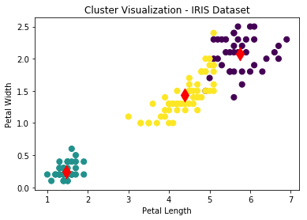

```python
# Plotting the Clusters Centroids and plot them on real values
plt.scatter(iris["petal length (cm)"],iris["petal width (cm)"], c = pred, s = 50)
plt.scatter(centroid[:, 2], centroid[:, 3], marker = "d", c = "red", s = 140)
plt.xlabel("Petal Length")
plt.ylabel("Petal Width")
plt.title("Cluster Visualization - IRIS Dataset")
plt.show()
```